# martah_OriginalHomeworkCode_03

Marta

10/1/2021

Populating in the csv file

```r
x<- curl('https://raw.githubusercontent.com/fuzzyatelin/fuzzyatelin.github.io/master/AN588_Fall21/zombies.csv')
zombies <- read.csv(x, header=TRUE, stringsAsFactors = FALSE)
head(zombies)
```

```
##   id first_name last_name gender   height   weight zombies_killed
## 1  1      Sarah    Little Female 62.88951 132.0872              2
## 2  2       Mark    Duncan   Male 67.80277 146.3753              5
## 3  3    Brandon     Perez   Male 72.12908 152.9370              1
## 4  4      Roger   Coleman   Male 66.78484 129.7418              5
## 5  5      Tammy    Powell Female 64.71832 132.4265              4
## 6  6    Anthony     Green   Male 71.24326 152.5246              1
##   years_of_education                           major      age
## 1                  1                medicine/nursing 17.64275
## 2                  3 criminal justice administration 22.58951
## 3                  1                       education 21.91276
## 4                  6                  energy studies 18.19058
## 5                  3                       logistics 21.10399
## 6                  4                  energy studies 21.48355
```

```r
summary(zombies) #just checking out the data, looks like everything is all loaded in!
```

```
##        id          first_name         last_name            gender
##  Min.   :   1.0   Length:1000        Length:1000        Length:1000
##  1st Qu.: 250.8   Class :character   Class :character   Class :character
##  Median : 500.5   Mode  :character   Mode  :character   Mode  :character
##  Mean   : 500.5
##  3rd Qu.: 750.2
##  Max.   :1000.0
##      height          weight       zombies_killed   years_of_education
##  Min.   :54.15   Min.   : 90.29   Min.   : 0.000   Min.   :0.000
##  1st Qu.:64.68   1st Qu.:131.81   1st Qu.: 2.000   1st Qu.:2.000
##  Median :67.50   Median :142.89   Median : 3.000   Median :3.000
##  Mean   :67.63   Mean   :143.91   Mean   : 2.992   Mean   :2.996
##  3rd Qu.:70.38   3rd Qu.:156.28   3rd Qu.: 4.000   3rd Qu.:4.000
##  Max.   :80.53   Max.   :210.79   Max.   :11.000   Max.   :8.000
##     major                age
##  Length:1000        Min.   :10.66
##  Class :character   1st Qu.:18.07
##  Mode  :character   Median :19.90
##                     Mean   :20.05
##                     3rd Qu.:21.94
##                     Max.   :29.59
```

## Pop Mean and SD

*Calculate the population mean and standard deviation for each quantitative random variable (height, weight, age, number of zombies killed, and years of education). NOTE: You will not want to use the built in var() and sd() commands as these are for samples.*

```r
mean(zombies$height)
```

```
## [1] 67.6301
```

```r
mean(zombies$weight)
```

```
## [1] 143.9075
```

```r
mean(zombies$age)
```

```
## [1] 20.04696
```

```r
mean(zombies$zombies_killed)
```

```
## [1] 2.992
```

```r
mean(zombies$years_of_education)#i'm going through and individual doing each mean but i would like to run them all at the same time.
```

```
## [1] 2.996
```

Now for sd I think I have to do the variance first because running the code for just the sd function doesn’t work??

```r
variance <- function(x) {
    sum((x - mean(x))^2)/(length(x))
} #this is setting up the variance function outside of the sd function so i can slim down the second function
sd <- function(x) {
    sqrt(variance(x))
}
```

```r
sd(zombies$height)
```

```
## [1] 4.30797
```

```r
sd(zombies$weight)
```

```
## [1] 18.39186
```

```r
sd(zombies$age)
```

```
## [1] 2.963583
```

```r
sd(zombies$zombies_killed)
```

```
## [1] 1.747551
```

```r
sd(zombies$years_of_education)
```

```
## [1] 1.675704
```

I have trouble figuring out what magnitude we should be in? So I can’t tell if these values are too high or too low.

## GGPlot Boxplots

*Use {ggplot} to make boxplots of each of these variables by gender.*

```r
male <- zombies[grep("Male", zombies$gender), ]
head(male)#I'm just creating two new data frames with just the male and female values
```

```
##    id first_name last_name gender   height   weight zombies_killed
## 2   2       Mark    Duncan   Male 67.80277 146.3753              5
## 3   3    Brandon     Perez   Male 72.12908 152.9370              1
## 4   4      Roger   Coleman   Male 66.78484 129.7418              5
## 6   6    Anthony     Green   Male 71.24326 152.5246              1
## 9   9     Steven      Long   Male 68.59963 152.9015              9
## 10 10    Russell    Chavez   Male 72.81769 168.5616              2
##    years_of_education                           major      age
## 2                   3 criminal justice administration 22.58951
## 3                   1                       education 21.91276
## 4                   6                  energy studies 18.19058
## 6                   4                  energy studies 21.48355
## 9                   3                   communication 17.34933
## 10                  3               military strategy 21.50798
```

```r
female <- zombies[grep("Female", zombies$gender), ]
head(female)
```

```
##    id first_name last_name gender   height   weight zombies_killed
## 1   1      Sarah    Little Female 62.88951 132.0872              2
## 5   5      Tammy    Powell Female 64.71832 132.4265              4
## 7   7    Theresa  Hamilton Female 70.26459 160.2569              0
## 8   8    Phyllis   Jenkins Female 59.82760 108.8093              4
## 14 14     Louise      Hall Female 65.88747 131.5336              5
## 18 18       Anne     Garza Female 62.74435 127.1145              3
##    years_of_education                           major      age
## 1                   1                medicine/nursing 17.64275
## 5                   3                       logistics 21.10399
## 7                   4                      psychology 20.53096
## 8                   0                          botany 15.94527
## 14                  5          mechanical engineering 19.21670
## 18                  5 criminal justice administration 19.58134
```

I ended up not using this lmao cause I spent too long trying to turn these into graphs and then i realized its each mean and sd, not the combined means and sds for each gender group *but i also though it was cool so i kept it here just to look at lmao*

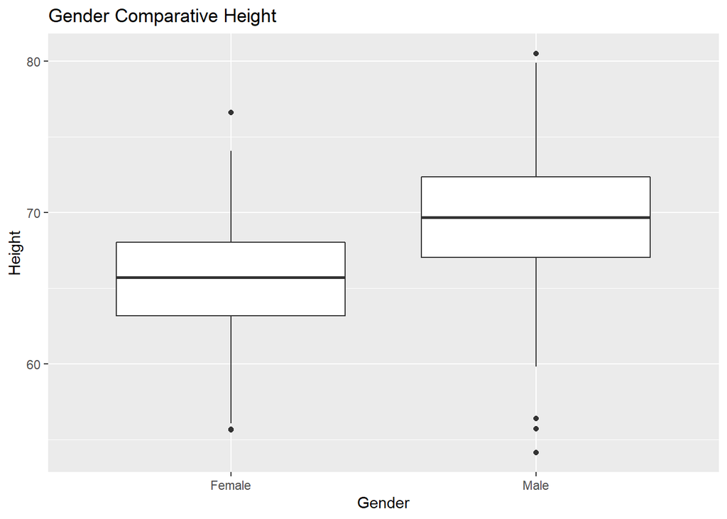

```r
par(mfrow = c(2, 3)) #I would really like to be able to view all my graphs next to each other but this isn't working, am I missing something?
gender_height<- ggplot(data = zombies, aes(x = gender, y = height)) + geom_boxplot() + labs( x = "Gender", y = "Height",
title ="Gender Comparative Height",)

gender_weight<- ggplot(data = zombies, aes(x = gender, y = weight)) + geom_boxplot()

gender_age<- ggplot(data = zombies, aes(x = gender, y = age)) + geom_boxplot()

gender_zombies_killed<- ggplot(data = zombies, aes(x = gender, y = zombies_killed)) + geom_boxplot()

gender_education<- ggplot(data = zombies, aes(x = gender, y = years_of_education)) + geom_boxplot()

gender_height
```

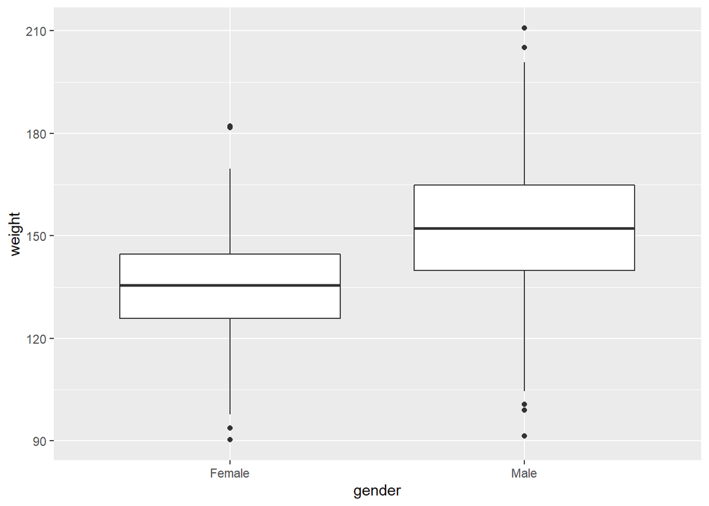

```r
gender_weight
```

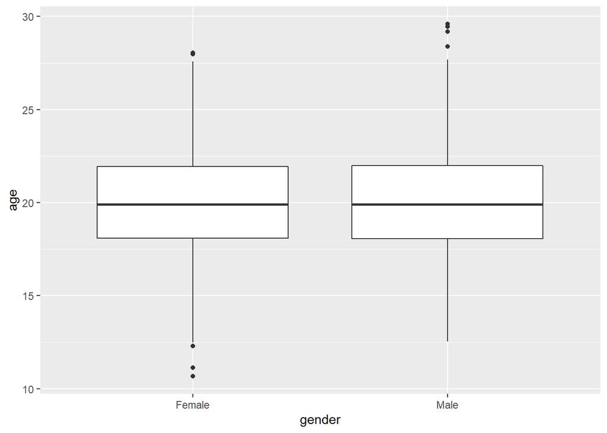

```r
gender_age
```

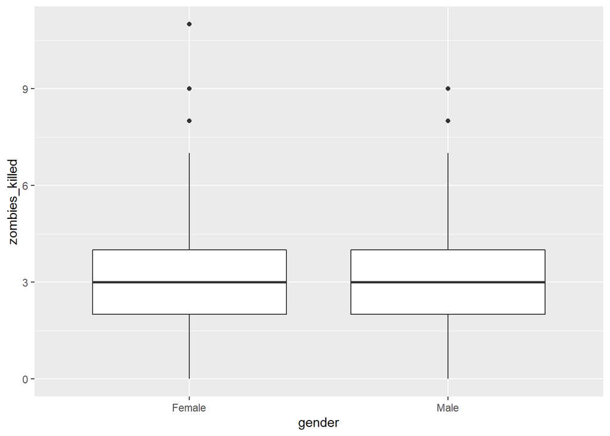

```r
gender_zombies_killed
```

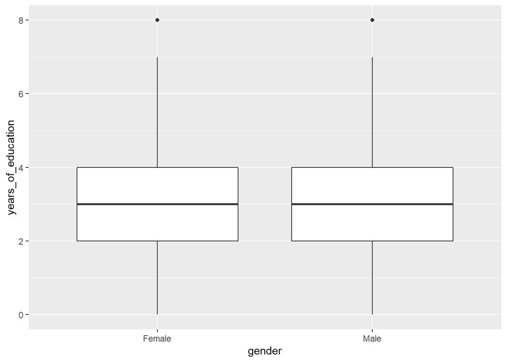

```r
gender_education
```

I literally just copy pasted from he ggplot cheat sheet so I’m not sure if my syntax is correct?? The `+` between arguments really throws me off.

## GGPlot Scatterplots

*Use {ggplot} to make scatterplots of height and weight in relation to age. Do these variables seem to be related? In what way?*

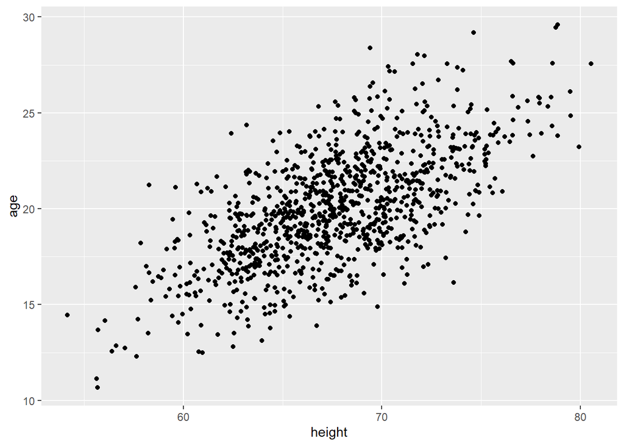

```r
height_age <- ggplot(data = zombies, aes(x = height, y = age)) + geom_point()
height_age
```

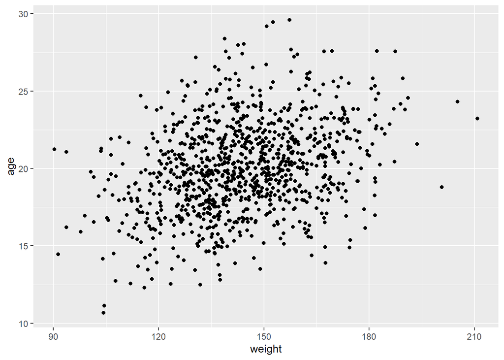

```r
weight_age <- ggplot(data = zombies, aes(x = weight, y = age)) + geom_point()
weight_age #gonna be real here i used point instead of jitter because there were no other values to put in for point so if jitter makes more sense i need help identifying 'area'
```

Height and age certainly have a correlation with height increasing with age. However, it appears that weight is highly variable among all ages.

## Q-Q Plots

*Using histograms and Q-Q plots, check whether the quantitative variables seem to be drawn from a normal distribution. Which seem to be and which do not (hint: not all are drawn from the normal distribution)? For those that are not normal, can you determine from which common distribution they are drawn?*

I think the best approach is to go variable by variable and create a histogram and a qqplot

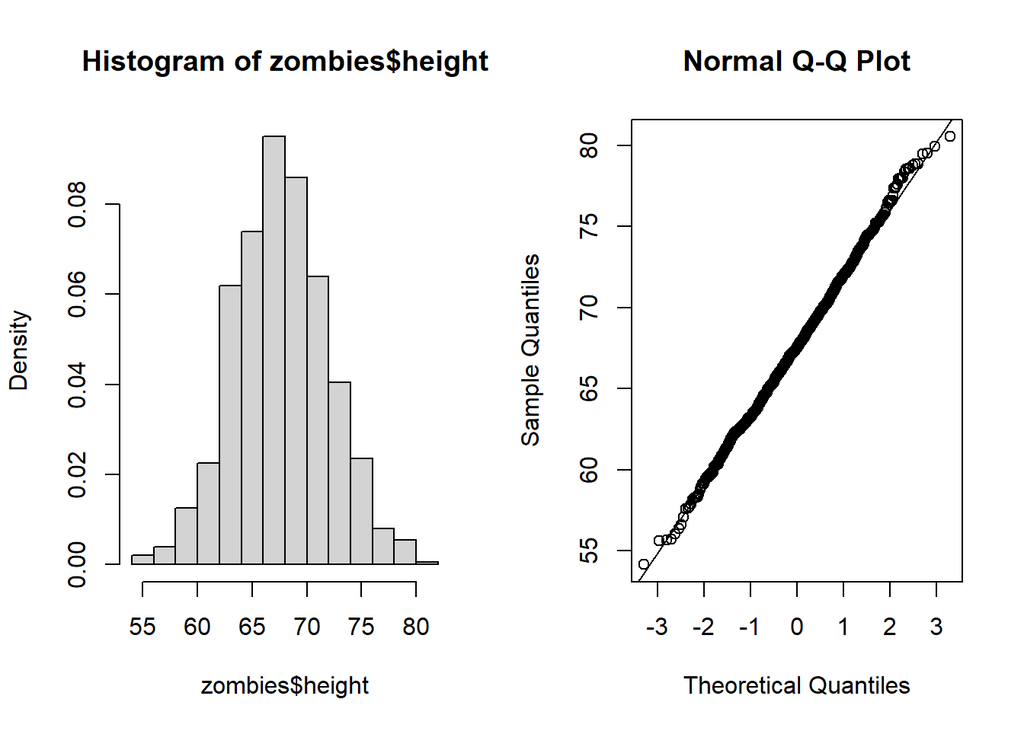

```r
par(mfrow = c(1, 2))# I could not figure out how else to view the histogram
hist(zombies$height, freq = F, probability = T) #Frequency and probability are included in histograms in the modules so i included them here but i don't see their point
qqnorm(zombies$height)
qqline(zombies$height)
```

Looks like normal distribution for height.

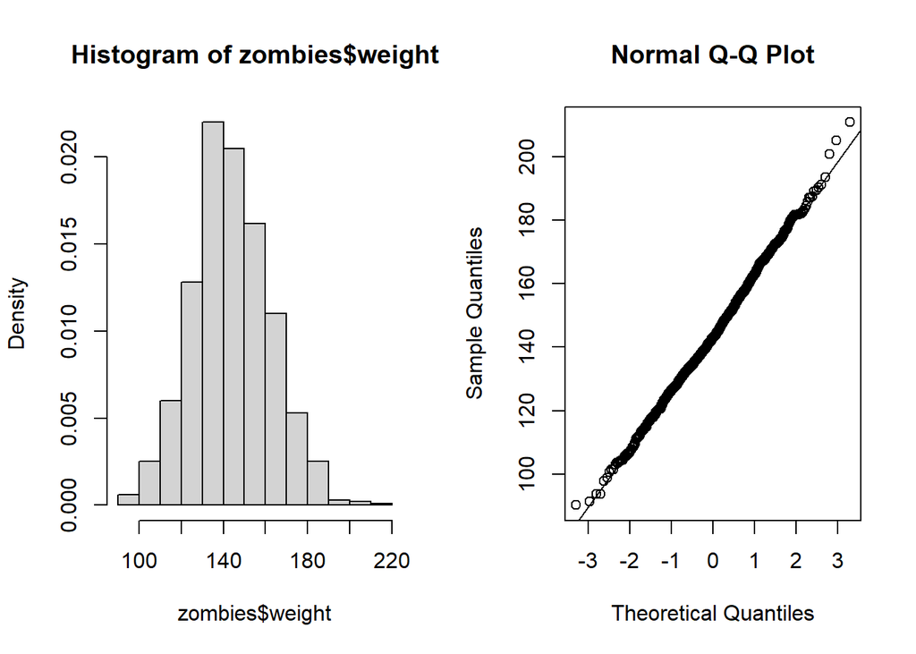

```r
par(mfrow = c(1, 2))# I could not figure out how else to view the histogram
hist(zombies$weight, freq = F, probability = T) #Frequency and probability are included in histograms in the modules so i included them here but i don't see their point
qqnorm(zombies$weight)
qqline(zombies$weight)
```

Looks like normal distribution for weight.

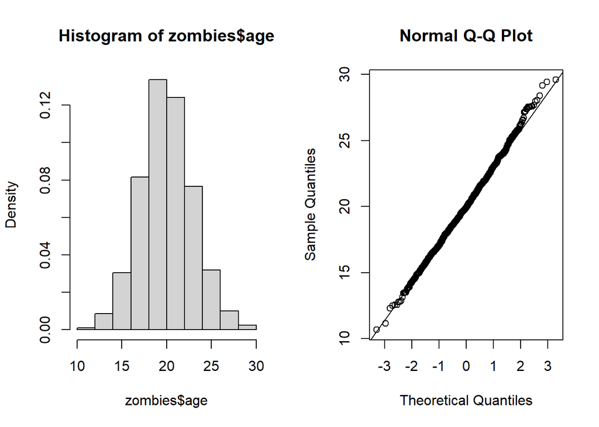

```r
par(mfrow = c(1, 2))# I could not figure out how else to view the histogram
hist(zombies$age, freq = F, probability = T) #Frequency and probability are included in histograms in the modules so i included them here but i don't see their point
qqnorm(zombies$age)
qqline(zombies$age)
```

Looks like normal distribution for age.

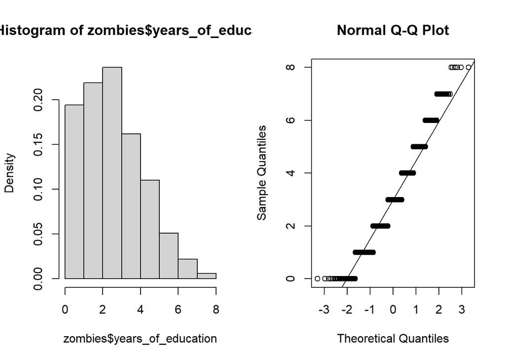

```r
par(mfrow = c(1, 2))# I could not figure out how else to view the histogram
hist(zombies$years_of_education, freq = F, probability = T) #Frequency and probability are included in histograms in the modules so i included them here but i don't see their point
qqnorm(zombies$years_of_education)
qqline(zombies$years_of_education)
```

Non-normal distribution for education.

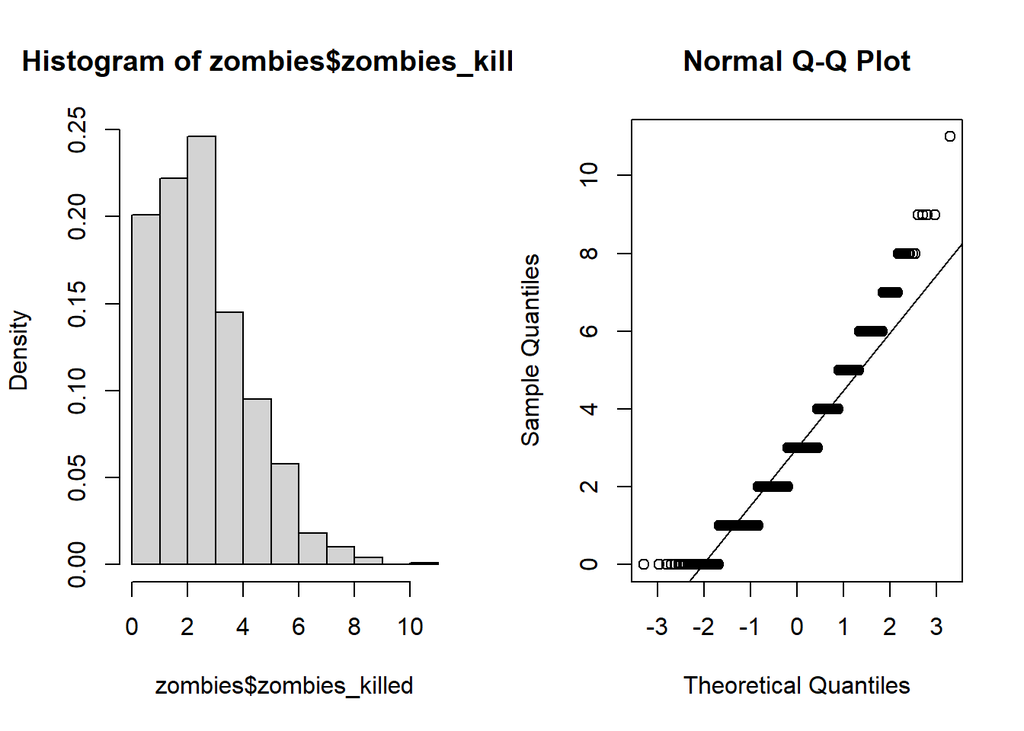

```r
par(mfrow = c(1, 2))# I could not figure out how else to view the histogram
hist(zombies$zombies_killed, freq = F, probability = T) #Frequency and probability are included in histograms in the modules so i included them here but i don't see their point
qqnorm(zombies$zombies_killed)
qqline(zombies$zombies_killed)
```

## One Set of 30

*Now use the sample() function to sample ONE subset of 30 zombie survivors (without replacement) from this population and calculate the mean and sample standard deviation for each variable. Also estimate the standard error for each variable, and construct the 95% confidence interval for each mean. Note that for the variables that are not drawn from the normal distribution, you may need to base your estimate of the CIs on slightly different code than for the normal…*

```r
set.seed(1)
sample1<- sample(zombies$id, size = 30, replace = FALSE)
sample1 #This just returns the id instead of the whole row
```

```
##  [1] 836 679 129 930 509 471 299 270 978 187 307 597 277 874 950 494 330 775 841
## [20] 591 725  37 105 729 878 485 677 802 987 382
```

`group <- zombies[grep(group1, zombies$id), ]` I also tried this which did not work because grep is for characters but I think if I knew the function to replace grep this would be closer

```r
group1<- zombies[sample1, ]#I'm manually going to overwrite and populate this just cause idk how else to fix the top which i think means i can do `group1<- zombies[sample(zombies$id, size = 30, replace = false)]`
group1
```

```
##      id  first_name last_name gender   height   weight zombies_killed
## 836 836       Susan   Hawkins Female 69.35963 133.1018              3
## 679 679    Benjamin      Ward   Male 61.95252 139.9611              2
## 129 129      Martin    Wagner   Male 70.26668 154.6746              2
## 930 930       Keith    Wagner   Male 63.24096 132.8480              3
## 509 509       Doris      Lane Female 62.33275 134.0491              3
## 471 471    Jennifer  Williams Female 62.29205 144.9394              2
## 299 299       Kelly     Burke Female 69.91124 145.7389              5
## 270 270 Christopher       Lee   Male 67.64806 130.5163              2
## 978 978      Willie  Richards   Male 64.73728 133.3641              5
## 187 187         Ann      Reid Female 71.02192 141.7984              2
## 307 307        Judy    Peters Female 63.76315 127.8650              4
## 597 597       Linda Patterson Female 63.14829 106.4643              2
## 277 277      Carlos Alexander   Male 75.21887 176.9457              3
## 874 874        Sean    Brooks   Male 68.52690 126.8207              1
```

[output cut: 47 more lines]

```r
mean(group1$height)
```

```
## [1] 66.88522
```

```r
mean(group1$weight)
```

```
## [1] 142.2536
```

```r
mean(group1$age)
```

```
## [1] 19.68657
```

```r
mean(group1$zombies_killed)
```

```
## [1] 3.066667
```

```r
mean(group1$years_of_education)
```

```
## [1] 2.966667
```

```r
sd(group1$height)
```

```
## [1] 3.672259
```

```r
sd(group1$weight)
```

```
## [1] 15.95385
```

```r
sd(group1$age)
```

```
## [1] 2.910717
```

```r
sd(group1$zombies_killed)
```

```
## [1] 1.651935
```

```r
sd(group1$years_of_education)
```

```
## [1] 1.662996
```

This is were it gets very confusing I thought the CIs were fairly stable as in they didn’t really change so idk how to calculate what I think would be new alpha values?

## One Hundred Sets of 30

*Now draw 99 more random samples of 30 zombie apocalypse survivors, and calculate the mean for each variable for each of these samples. Together with the first sample you drew, you now have a set of 100 means for each variable (each based on 30 observations), which constitutes a sampling distribution for each variable. What are the means and standard deviations of this distribution of means for each variable? How do the standard deviations of means compare to the standard errors estimated in [5]? What do these sampling distributions look like (a graph might help here)? Are they normally distributed? What about for those variables that you concluded were not originally drawn from a normal distribution?*

```r
set.seed(1)
k <- 99  # number of samples
n <- 30  # size of each sample
s <- NULL  # dummy variable to hold each sample, can i add my own sample in here to add the first group?
for (i in 1:k) {
    s[[i]] <- zombies[sample(zombies$id, size = n, replace = FALSE), ]
}
s[[100]]<- group1 #lmao this seems too easy i definitely think its wrong
head(s) #fun fact i originally just ran `s` and almost crashed my program
```

```
## [[1]]
##      id  first_name last_name gender   height   weight zombies_killed
## 836 836       Susan   Hawkins Female 69.35963 133.1018              3
## 679 679    Benjamin      Ward   Male 61.95252 139.9611              2
## 129 129      Martin    Wagner   Male 70.26668 154.6746              2
## 930 930       Keith    Wagner   Male 63.24096 132.8480              3
## 509 509       Doris      Lane Female 62.33275 134.0491              3
## 471 471    Jennifer  Williams Female 62.29205 144.9394              2
## 299 299       Kelly     Burke Female 69.91124 145.7389              5
## 270 270 Christopher       Lee   Male 67.64806 130.5163              2
## 978 978      Willie  Richards   Male 64.73728 133.3641              5
## 187 187         Ann      Reid Female 71.02192 141.7984              2
## 307 307        Judy    Peters Female 63.76315 127.8650              4
## 597 597       Linda Patterson Female 63.14829 106.4643              2
## 277 277      Carlos Alexander   Male 75.21887 176.9457              3
```

[output cut: 368 more lines]

```r
s[[100]] #ok this works but i think there's another way because then these values were replaced and maybe picked again in the sampling
```

```
##      id  first_name last_name gender   height   weight zombies_killed
## 836 836       Susan   Hawkins Female 69.35963 133.1018              3
## 679 679    Benjamin      Ward   Male 61.95252 139.9611              2
## 129 129      Martin    Wagner   Male 70.26668 154.6746              2
## 930 930       Keith    Wagner   Male 63.24096 132.8480              3
## 509 509       Doris      Lane Female 62.33275 134.0491              3
## 471 471    Jennifer  Williams Female 62.29205 144.9394              2
## 299 299       Kelly     Burke Female 69.91124 145.7389              5
## 270 270 Christopher       Lee   Male 67.64806 130.5163              2
## 978 978      Willie  Richards   Male 64.73728 133.3641              5
## 187 187         Ann      Reid Female 71.02192 141.7984              2
## 307 307        Judy    Peters Female 63.76315 127.8650              4
## 597 597       Linda Patterson Female 63.14829 106.4643              2
## 277 277      Carlos Alexander   Male 75.21887 176.9457              3
## 874 874        Sean    Brooks   Male 68.52690 126.8207              1
```

[output cut: 47 more lines]

## Challenges

1. I had trouble viewing some of my data the way I wanted to. Some of the graphs I wanted plotted together with `par` which didn’t always work. Also in a couple spots like at the top with mean I wanted to calculate all my variables at once and have it return different values but it did not like that.
2. I am really unsure how to determine the type of distribution just going off the q-q plot. I understand how it shows that the distribution is non-normal but when it come to determining type, is there a q-q plot equivalent for each type of distribution?
3. For the ggplots I was just picking ones that didn’t require extra information so I’m not sure if they are the est suited, but I don’ really understand the extra arguments for some of the geom_functions.
4. For picking a group I was really confused on how to get all of the columns included, I’m stuck with just going with `x = zombies$id` which just gave me a vector of integers. How can I sample the whole row?
5. The for loooooooooooooops :,( ok honestly not hat bad I put this here preemptivly thinking they would be harder lol. However, idk how to put in my own sample and enforce the replace = f because there’s a good chance those people were picked again during the for loop since I put them in after replace = false. If I put it group1 first and have `i in 2:k` where k = 100 would that work?